# F1 2017 Austria, Qualifying

Drivers progressed through the qualifying session as follows:

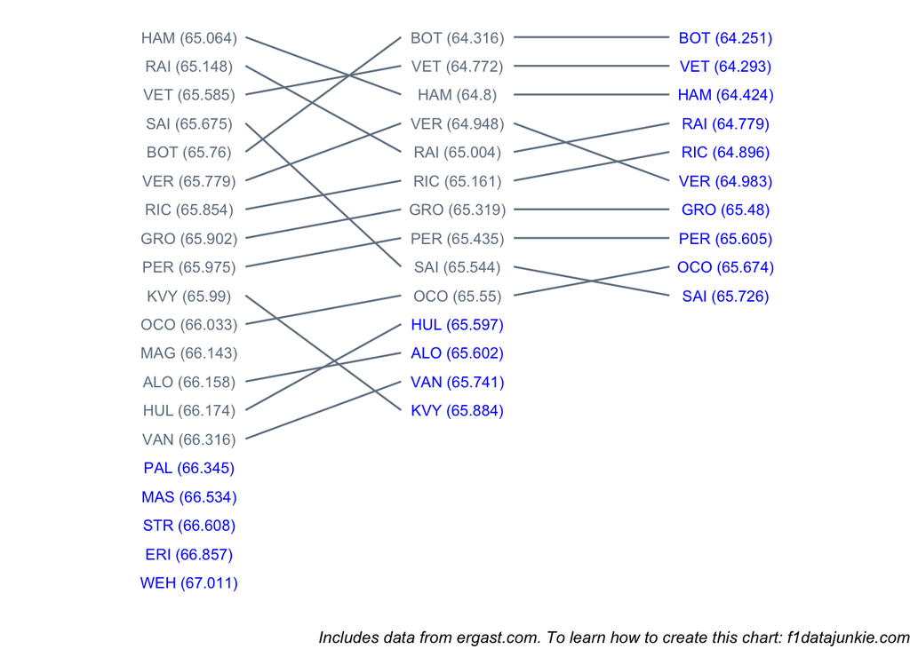

Going from Q1 to Q2:

- all drivers improved on their best laptime from the previous session

Going from Q2 to Q3:

- VER failed to improve his time, recording 64.983 compared to 64.948 (0.035s slower)
- GRO failed to improve his time, recording 65.48 compared to 65.319 (0.161s slower)
- PER failed to improve his time, recording 65.605 compared to 65.435 (0.17s slower)
- OCO failed to improve his time, recording 65.674 compared to 65.55 (0.124s slower)
- SAI failed to improve his time, recording 65.726 compared to 65.544 (0.182s slower)

Order change going from Q2 to Q3, along with laptime improvement (-ve is a better time in Q3)

```
##   driverName   imp1 driverName  imp2
## 1        RAI -0.225        VER 0.035
## 2        RIC -0.265        VER 0.035
## 3        OCO  0.124        SAI 0.182
```

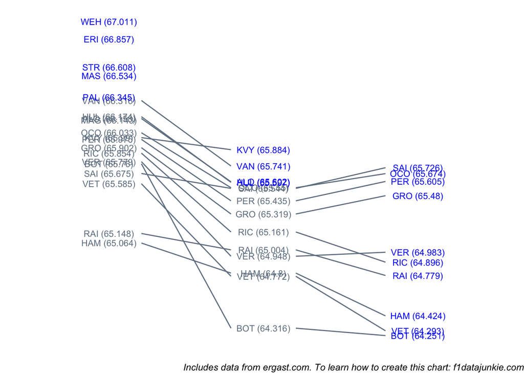

The official session results were recorded as follows:

| POS | DRIVER | Q1 | Q2 | Q3 |
| --- | --- | --- | --- | --- |
| 1 | BOT | 1:05.760 (5) | 1:04.316 (1) | 1:04.251 (1) |
| 2 | VET | 1:05.585 (3) | 1:04.772 (2) | 1:04.293 (2) |
| 3 | HAM | 1:05.064 (1) | 1:04.800 (3) | 1:04.424 (3) |
| 4 | RAI | 1:05.148 (2) | 1:05.004 (5) | 1:04.779 (4) |
| 5 | RIC | 1:05.854 (7) | 1:05.161 (6) | 1:04.896 (5) |
| 6 | VER | 1:05.779 (6) | 1:04.948 (4) | 1:04.983 (6) |
| 7 | GRO | 1:05.902 (8) | 1:05.319 (7) | 1:05.480 (7) |
| 8 | PER | 1:05.975 (9) | 1:05.435 (8) | 1:05.605 (8) |
| 9 | OCO | 1:06.033 (11) | 1:05.550 (10) | 1:05.674 (9) |
| 10 | SAI | 1:05.675 (4) | 1:05.544 (9) | 1:05.726 (10) |
| 11 | HUL | 1:06.174 (14) | 1:05.597 (11) |  |
| 12 | ALO | 1:06.158 (13) | 1:05.602 (12) |  |
| 13 | VAN | 1:06.316 (15) | 1:05.741 (13) |  |
| 14 | KVY | 1:05.990 (10) | 1:05.884 (14) |  |
| 15 | MAG | 1:06.143 (12) |  |  |
| 16 | PAL | 1:06.345 (16) |  |  |
| 17 | MAS | 1:06.534 (17) |  |  |
| 18 | STR | 1:06.608 (18) |  |  |
| 19 | ERI | 1:06.857 (19) |  |  |
| 20 | WEH | 1:07.011 (20) |  |  |

## Session Utilisation

Activity throughout the three qualification sessions took place as follows:

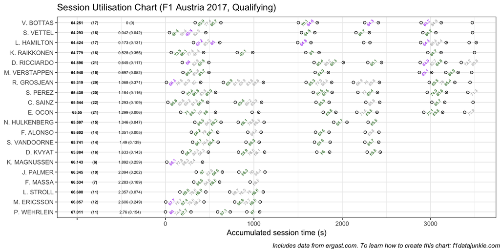

## Q1

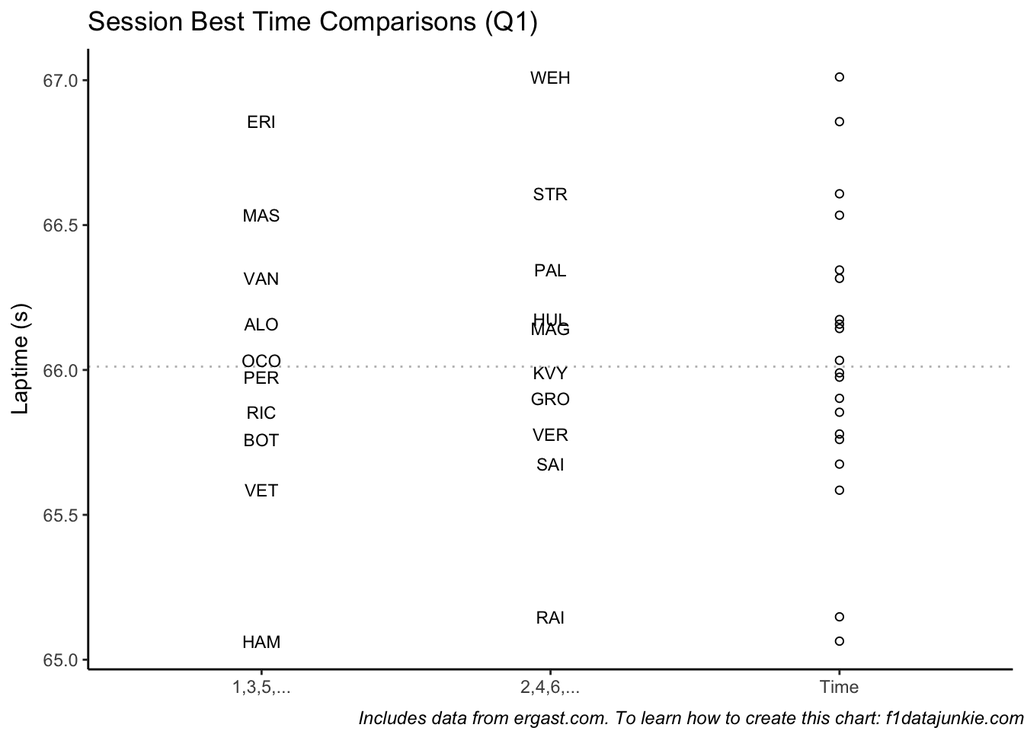

### Cut-off Time Evolution

The cut-off time in Q1 evolved as follows:

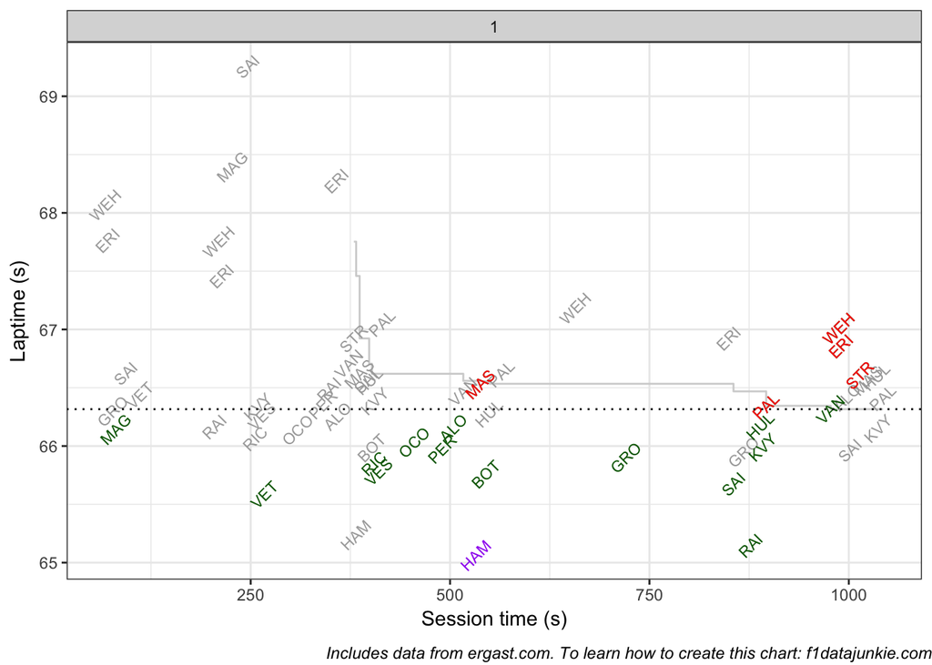

## Q2

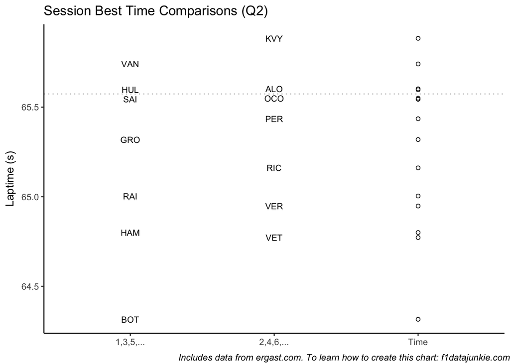

### Cut-off Time Evolution

The cut-off time in Q2 evolved as follows:

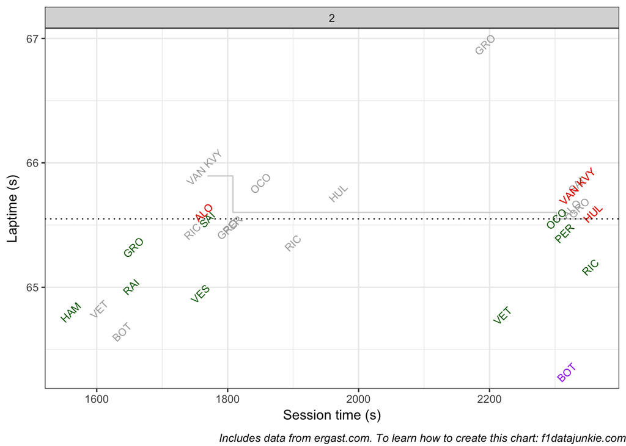

## Q3

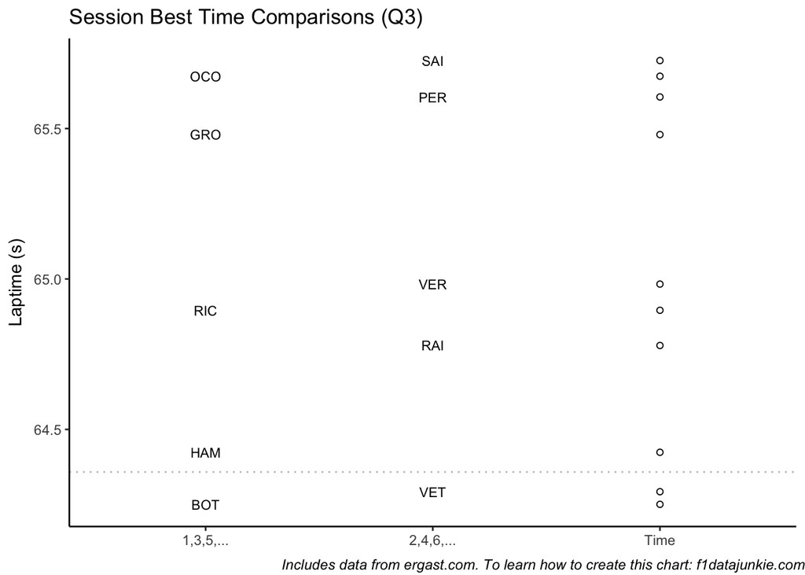

### Front Row Cut-off Time Evolution

The cut-off time in Q3 evolved as follows:

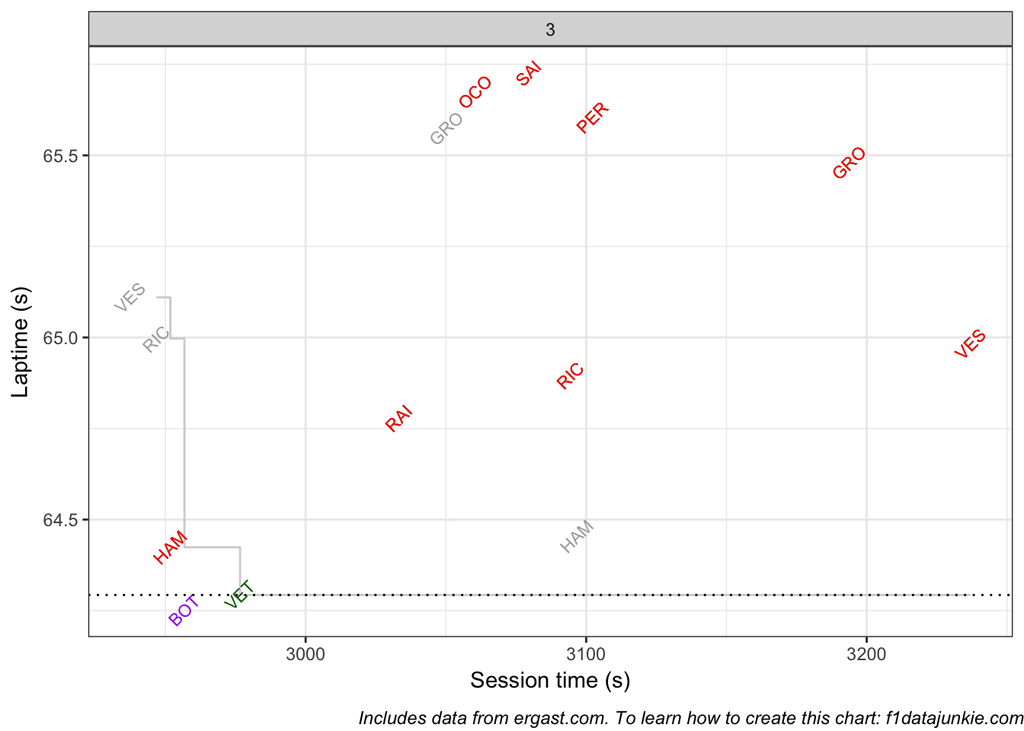

To learn how to wrangle F1 results and timing data to create charts like these, see f1datajunkie.com or [buy the *Wrangling F1 Data With R* book](https://leanpub.com/wranglingf1datawithr).